# Cyclistic Bike Share Casestudy

Minty Vo

2022/02/04

*Welcome to my Cyclistic Bike Share data analysis case study*

## Scenario

Cyclistic is the bike-share company with more than 5.800 bikes and 600 docking stations all over Chicago.Lily Moreno, the director of marketing, wants to start a new marketing strategy to convert casual riders into annual members. She believes with the right campaign there is a very good chance of conversion with the company’s name recognition and access to user-friendly bike options. These user-friendly bike options include reclining bikes, hand tricycles, and cargo bikes which makes Cyclistic more inclusive to people with disabilities and riders who can’t use a standard two-wheeled bike. Lily has tasked the marketing analytics team to analyze past user data to find trends and habits of Cyclistic’s users to help create this marketing campaign.

**I will follow these steps of the data analysis process: ask, prepare, process, analyze, share, and act.**

## Ask

**Business task**

The new marketing strategy requires three components: behavioral differences between annual members and casual riders, reasons why a casual rider would buy Cyclistic annual memberships, and how digital media can influence casual riders to becoming members. The marketing analytics team is tasked with using past user data to find the behavioral differences between annual members and casual riders and report their finding

## Process

**Downloading the data**

User data from the past 12 months, February 2021 - January 2022 has been made available. Each data set is in csv format and details every ride logged by Cyclistic customers. This data has been made publicly available via license by Motivate International Inc. and the city of Chicago available here. All user’s personal data has been scrubbed for privacy.

**Loading packages**

I am going to install and load some R packages that will help in my analysis

```r
# install.packages("tidyverse")
# install.packages("lubridate")
# install.packages("dplyr")
# install.packages("ggplot2")
# install.packages("tidyr")
# install.packages("here")
# install.packages("skimr")
# install.packages("janitor")

library(tidyverse)
library(lubridate)
library(dplyr)
library(ggplot2)
library(tidyr)
library(here)
library(skimr)
library(janitor)
```

Now I import all the dataset on RStudio and use head(), str() to quickly review the data

```r
setwd("/Users/minty/Developer/Cyclistic-Bike-casestudy")
feb2021 <- read_csv("202102-divvy-tripdata.csv")
str(feb2021)
head(feb2021)

mar2021 <- read_csv("202103-divvy-tripdata.csv")
str(mar2021)
head(mar2021)

apr2021 <- read_csv("202104-divvy-tripdata.csv")
str(apr2021)
head(apr2021)

ma2021 <- read_csv("202105-divvy-tripdata.csv")
str(ma2021)
head(ma2021)

jun2021 <- read_csv("202106-divvy-tripdata.csv")
str(jun2021)
head(jun2021)

jul2021 <- read_csv("202107-divvy-tripdata.csv")
str(jul2021)
head(jul2021)

aug2021 <- read_csv("202108-divvy-tripdata.csv")
str(aug2021)
head(aug2021)

sep2021 <- read_csv("202109-divvy-tripdata.csv")
str(sep2021)
head(sep2021)

oct2021 <- read_csv("202110-divvy-tripdata.csv")
str(oct2021)
head(oct2021)

nov2021 <- read_csv("202111-divvy-tripdata.csv")
str(nov2021)
head(nov2021)

dec2021 <- read_csv("202112-divvy-tripdata.csv")
str(dec2021)
head(dec2021)

jan2022 <- read_csv("202201-divvy-tripdata.csv")
str(jan2022)
head(jan2022)
```

Then I combine all the data into one table

```r
bike_data <- rbind(feb2021, mar2021, apr2021, ma2021, jun2021, jul2021, aug2021, sep2021,oct2021, nov2021, dec2021, jan2022)
head(bike_data,10)
```

```
## # A tibble: 10 × 13
##    ride_id          rideable_type started_at          ended_at
##    <chr>            <chr>         <dttm>              <dttm>
##  1 89E7AA6C29227EFF classic_bike  2021-02-12 16:14:56 2021-02-12 16:21:43
##  2 0FEFDE2603568365 classic_bike  2021-02-14 17:52:38 2021-02-14 18:12:09
##  3 E6159D746B2DBB91 electric_bike 2021-02-09 19:10:18 2021-02-09 19:19:10
##  4 B32D3199F1C2E75B classic_bike  2021-02-02 17:49:41 2021-02-02 17:54:06
##  5 83E463F23575F4BF electric_bike 2021-02-23 15:07:23 2021-02-23 15:22:37
##  6 BDAA7E3494E8D545 electric_bike 2021-02-24 15:43:33 2021-02-24 15:49:05
##  7 A772742351171257 classic_bike  2021-02-01 17:47:42 2021-02-01 17:48:33
##  8 295476889D9B79F8 classic_bike  2021-02-11 18:33:53 2021-02-11 18:35:09
##  9 362087194BA4CC9A classic_bike  2021-02-27 15:13:39 2021-02-27 15:36:36
## 10 21630F715038CCB0 classic_bike  2021-02-20 08:59:42 2021-02-20 09:17:04
## # … with 9 more variables: start_station_name <chr>, start_station_id <chr>,
## #   end_station_name <chr>, end_station_id <chr>, start_lat <dbl>,
## #   start_lng <dbl>, end_lat <dbl>, end_lng <dbl>, member_casual <chr>
```

I make a copy of the data to have a backup

```r
bike_data1 <- bike_data
```

I add some relevant columns to help me analyze the data easier

```r
# Add a date column
bike_data1$date <- as.Date(bike_data1$started_at)
head(bike_data1$date)
```

```
## [1] "2021-02-12" "2021-02-14" "2021-02-09" "2021-02-02" "2021-02-23"
## [6] "2021-02-24"
```

```r
# Add a month column
bike_data1$month <- format(as.Date(bike_data1$started_at), "%b_%y")
head(bike_data1$month)
```

```
## [1] "Feb_21" "Feb_21" "Feb_21" "Feb_21" "Feb_21" "Feb_21"
```

```r
# Add a day column
bike_data1$day <- format(as.Date(bike_data1$date), "%d")
head(bike_data1$day)
```

```
## [1] "12" "14" "09" "02" "23" "24"
```

```r
# Add a year column
bike_data1$year <- format(as.Date(bike_data1$date), "%Y")
head(bike_data1$year)
```

```
## [1] "2021" "2021" "2021" "2021" "2021" "2021"
```

```r
# Add a day of week column
bike_data1$weekday <- format(as.Date(bike_data1$date), "%A")
head(bike_data1$weekday)
```

```
## [1] "Friday"    "Sunday"    "Tuesday"   "Tuesday"   "Tuesday"   "Wednesday"
```

```r
# Add a time started column
bike_data1$time <- format(bike_data1$started_at, format = "%H:%M")
head(bike_data1$time)
```

```
## [1] "16:14" "17:52" "19:10" "17:49" "15:07" "15:43"
```

```r
# Change format for the time column for purposes later
bike_data1$time <- as.POSIXct(bike_data1$time, format = "%H:%M")
head(bike_data1$time)
```

```
## [1] "2022-02-11 16:14:00 PST" "2022-02-11 17:52:00 PST"
## [3] "2022-02-11 19:10:00 PST" "2022-02-11 17:49:00 PST"
## [5] "2022-02-11 15:07:00 PST" "2022-02-11 15:43:00 PST"
```

```r
#calculate ride length in minutes
bike_data1$ride_length <- (as.double(difftime(bike_data1$ended_at, bike_data1$started_at))) /60
head(bike_data1$ride_length)
```

```
## [1]  6.783333 19.516667  8.866667  4.416667 15.233333  5.533333
```

Then I examine the new data frame

```r
str(bike_data1)
```

```
## spec_tbl_df [5,601,999 × 20] (S3: spec_tbl_df/tbl_df/tbl/data.frame)
##  $ ride_id           : chr [1:5601999] "89E7AA6C29227EFF" "0FEFDE2603568365" "E6159D746B2DBB91" "B32D3199F1C2E75B" ...
##  $ rideable_type     : chr [1:5601999] "classic_bike" "classic_bike" "electric_bike" "classic_bike" ...
##  $ started_at        : POSIXct[1:5601999], format: "2021-02-12 16:14:56" "2021-02-14 17:52:38" ...
##  $ ended_at          : POSIXct[1:5601999], format: "2021-02-12 16:21:43" "2021-02-14 18:12:09" ...
##  $ start_station_name: chr [1:5601999] "Glenwood Ave & Touhy Ave" "Glenwood Ave & Touhy Ave" "Clark St & Lake St" "Wood St & Chicago Ave" ...
##  $ start_station_id  : chr [1:5601999] "525" "525" "KA1503000012" "637" ...
##  $ end_station_name  : chr [1:5601999] "Sheridan Rd & Columbia Ave" "Bosworth Ave & Howard St" "State St & Randolph St" "Honore St & Division St" ...
##  $ end_station_id    : chr [1:5601999] "660" "16806" "TA1305000029" "TA1305000034" ...
##  $ start_lat         : num [1:5601999] 42 42 41.9 41.9 41.8 ...
##  $ start_lng         : num [1:5601999] -87.7 -87.7 -87.6 -87.7 -87.6 ...
##  $ end_lat           : num [1:5601999] 42 42 41.9 41.9 41.8 ...
##  $ end_lng           : num [1:5601999] -87.7 -87.7 -87.6 -87.7 -87.6 ...
##  $ member_casual     : chr [1:5601999] "member" "casual" "member" "member" ...
##  $ date              : Date[1:5601999], format: "2021-02-12" "2021-02-14" ...
##  $ month             : chr [1:5601999] "Feb_21" "Feb_21" "Feb_21" "Feb_21" ...
##  $ day               : chr [1:5601999] "12" "14" "09" "02" ...
##  $ year              : chr [1:5601999] "2021" "2021" "2021" "2021" ...
##  $ weekday           : chr [1:5601999] "Friday" "Sunday" "Tuesday" "Tuesday" ...
##  $ time              : POSIXct[1:5601999], format: "2022-02-11 16:14:00" "2022-02-11 17:52:00" ...
##  $ ride_length       : num [1:5601999] 6.78 19.52 8.87 4.42 15.23 ...
##  - attr(*, "spec")=
##   .. cols(
##   ..   ride_id = col_character(),
##   ..   rideable_type = col_character(),
##   ..   started_at = col_datetime(format = ""),
##   ..   ended_at = col_datetime(format = ""),
##   ..   start_station_name = col_character(),
##   ..   start_station_id = col_character(),
##   ..   end_station_name = col_character(),
##   ..   end_station_id = col_character(),
##   ..   start_lat = col_double(),
##   ..   start_lng = col_double(),
##   ..   end_lat = col_double(),
##   ..   end_lng = col_double(),
##   ..   member_casual = col_character()
##   .. )
##  - attr(*, "problems")=<externalptr>
```

```r
colnames(bike_data1)
```

```
##  [1] "ride_id"            "rideable_type"      "started_at"
##  [4] "ended_at"           "start_station_name" "start_station_id"
##  [7] "end_station_name"   "end_station_id"     "start_lat"
## [10] "start_lng"          "end_lat"            "end_lng"
## [13] "member_casual"      "date"               "month"
## [16] "day"                "year"               "weekday"
## [19] "time"               "ride_length"
```

```r
dim(bike_data1)
```

```
## [1] 5601999      20
```

```r
nrow(bike_data1)
```

```
## [1] 5601999
```

```r
summary(bike_data1)
```

```
##    ride_id          rideable_type        started_at
##  Length:5601999     Length:5601999     Min.   :2021-02-01 00:55:44
##  Class :character   Class :character   1st Qu.:2021-06-11 12:40:12
##  Mode  :character   Mode  :character   Median :2021-08-04 22:01:30
##                                        Mean   :2021-08-04 20:30:49
##                                        3rd Qu.:2021-09-28 16:39:49
##                                        Max.   :2022-01-31 23:58:37
##
##     ended_at                   start_station_name start_station_id
##  Min.   :2021-02-01 01:22:48   Length:5601999     Length:5601999
##  1st Qu.:2021-06-11 13:03:36   Class :character   Class :character
##  Median :2021-08-04 22:23:12   Mode  :character   Mode  :character
##  Mean   :2021-08-04 20:52:45
##  3rd Qu.:2021-09-28 16:55:21
##  Max.   :2022-02-01 01:46:16
##
##  end_station_name   end_station_id       start_lat       start_lng
##  Length:5601999     Length:5601999     Min.   :41.64   Min.   :-87.84
##  Class :character   Class :character   1st Qu.:41.88   1st Qu.:-87.66
##  Mode  :character   Mode  :character   Median :41.90   Median :-87.64
##                                        Mean   :41.90   Mean   :-87.65
##                                        3rd Qu.:41.93   3rd Qu.:-87.63
##                                        Max.   :45.64   Max.   :-73.80
##
##     end_lat         end_lng       member_casual           date
##  Min.   :41.39   Min.   :-88.97   Length:5601999     Min.   :2021-02-01
##  1st Qu.:41.88   1st Qu.:-87.66   Class :character   1st Qu.:2021-06-11
##  Median :41.90   Median :-87.64   Mode  :character   Median :2021-08-04
##  Mean   :41.90   Mean   :-87.65                      Mean   :2021-08-04
##  3rd Qu.:41.93   3rd Qu.:-87.63                      3rd Qu.:2021-09-28
##  Max.   :42.17   Max.   :-87.49                      Max.   :2022-01-31
##  NA's   :4754    NA's   :4754
##     month               day                year             weekday
##  Length:5601999     Length:5601999     Length:5601999     Length:5601999
##  Class :character   Class :character   Class :character   Class :character
##  Mode  :character   Mode  :character   Mode  :character   Mode  :character
##
##
##
##
##       time                      ride_length
##  Min.   :2022-02-11 00:00:00   Min.   :  -58.03
##  1st Qu.:2022-02-11 11:32:00   1st Qu.:    6.72
##  Median :2022-02-11 15:33:00   Median :   11.95
##  Mean   :2022-02-11 14:43:56   Mean   :   21.93
##  3rd Qu.:2022-02-11 18:22:00   3rd Qu.:   21.72
##  Max.   :2022-02-11 23:59:00   Max.   :55944.15
##
```

Now I start to clean the data

```r
# Remove duplicates
bike_data1 <- distinct(bike_data1)

# Get rid of negative ride
bike_data1 <- bike_data1[!bike_data1$ride_length<1,]
# Get rid of the ride that is longer than one day or 1440 mins
bike_data1 <- bike_data1[!bike_data1$ride_length>1440,]

# Change a few column names for clarification
bike_data1 <- rename(bike_data1, customer_type = member_casual)
bike_data1 <- rename(bike_data1, bike_type = rideable_type)

## Filter out data we will not be using and remove missing data
bike_data1 <- bike_data1 %>% select(bike_type, customer_type, started_at, date, month, day, year, weekday, time, ride_length)
drop_na(bike_data1)
```

```
## # A tibble: 5,512,267 × 10
##    bike_type     customer_type started_at          date       month  day   year
##    <chr>         <chr>         <dttm>              <date>     <chr>  <chr> <chr>
##  1 classic_bike  member        2021-02-12 16:14:56 2021-02-12 Feb_21 12    2021
##  2 classic_bike  casual        2021-02-14 17:52:38 2021-02-14 Feb_21 14    2021
##  3 electric_bike member        2021-02-09 19:10:18 2021-02-09 Feb_21 09    2021
##  4 classic_bike  member        2021-02-02 17:49:41 2021-02-02 Feb_21 02    2021
##  5 electric_bike member        2021-02-23 15:07:23 2021-02-23 Feb_21 23    2021
##  6 electric_bike casual        2021-02-24 15:43:33 2021-02-24 Feb_21 24    2021
##  7 classic_bike  member        2021-02-11 18:33:53 2021-02-11 Feb_21 11    2021
##  8 classic_bike  member        2021-02-27 15:13:39 2021-02-27 Feb_21 27    2021
##  9 classic_bike  member        2021-02-20 08:59:42 2021-02-20 Feb_21 20    2021
## 10 classic_bike  member        2021-02-20 16:45:11 2021-02-20 Feb_21 20    2021
## # … with 5,512,257 more rows, and 3 more variables: weekday <chr>, time <dttm>,
## #   ride_length <dbl>
```

```r
remove_empty(bike_data1)
```

```
## value for "which" not specified, defaulting to c("rows", "cols")
```

```
## # A tibble: 5,512,267 × 10
##    bike_type     customer_type started_at          date       month  day   year
##    <chr>         <chr>         <dttm>              <date>     <chr>  <chr> <chr>
##  1 classic_bike  member        2021-02-12 16:14:56 2021-02-12 Feb_21 12    2021
##  2 classic_bike  casual        2021-02-14 17:52:38 2021-02-14 Feb_21 14    2021
##  3 electric_bike member        2021-02-09 19:10:18 2021-02-09 Feb_21 09    2021
##  4 classic_bike  member        2021-02-02 17:49:41 2021-02-02 Feb_21 02    2021
##  5 electric_bike member        2021-02-23 15:07:23 2021-02-23 Feb_21 23    2021
##  6 electric_bike casual        2021-02-24 15:43:33 2021-02-24 Feb_21 24    2021
##  7 classic_bike  member        2021-02-11 18:33:53 2021-02-11 Feb_21 11    2021
##  8 classic_bike  member        2021-02-27 15:13:39 2021-02-27 Feb_21 27    2021
##  9 classic_bike  member        2021-02-20 08:59:42 2021-02-20 Feb_21 20    2021
## 10 classic_bike  member        2021-02-20 16:45:11 2021-02-20 Feb_21 20    2021
## # … with 5,512,257 more rows, and 3 more variables: weekday <chr>, time <dttm>,
## #   ride_length <dbl>
```

```r
remove_missing(bike_data1)
```

```
## # A tibble: 5,512,267 × 10
##    bike_type     customer_type started_at          date       month  day   year
##    <chr>         <chr>         <dttm>              <date>     <chr>  <chr> <chr>
##  1 classic_bike  member        2021-02-12 16:14:56 2021-02-12 Feb_21 12    2021
##  2 classic_bike  casual        2021-02-14 17:52:38 2021-02-14 Feb_21 14    2021
##  3 electric_bike member        2021-02-09 19:10:18 2021-02-09 Feb_21 09    2021
##  4 classic_bike  member        2021-02-02 17:49:41 2021-02-02 Feb_21 02    2021
##  5 electric_bike member        2021-02-23 15:07:23 2021-02-23 Feb_21 23    2021
##  6 electric_bike casual        2021-02-24 15:43:33 2021-02-24 Feb_21 24    2021
##  7 classic_bike  member        2021-02-11 18:33:53 2021-02-11 Feb_21 11    2021
##  8 classic_bike  member        2021-02-27 15:13:39 2021-02-27 Feb_21 27    2021
##  9 classic_bike  member        2021-02-20 08:59:42 2021-02-20 Feb_21 20    2021
## 10 classic_bike  member        2021-02-20 16:45:11 2021-02-20 Feb_21 20    2021
## # … with 5,512,257 more rows, and 3 more variables: weekday <chr>, time <dttm>,
## #   ride_length <dbl>
```

I order data to based on day of week and by month

```r
bike_data1$weekday <- ordered(bike_data1$weekday, levels=c("Monday", "Tuesday", "Wednesday", "Thursday", "Friday", "Saturday", "Sunday"))
bike_data1$month <- ordered(bike_data1$month, levels=c("Feb_21", "Mar_21", "Apr_21",  "May_21", "Jun_21","Jul_21", "Aug_21", "Sep_21", "Oct_21","Nov_21","Dec_21","Jan_2021"))
```

## Analyze

I use the summary() to look at min, max, median, and average ride lengths

```r
summary(bike_data1$ride_length)
```

```
##     Min.  1st Qu.   Median     Mean  3rd Qu.     Max.
##    1.000    6.917   12.133   19.742   21.917 1439.950
```

I examine the number of customers based on membership types

```r
table(bike_data1$customer_type)
```

```
##
##  casual  member
## 2491637 3020630
```

I check the total rides for each customer type in minutes

```r
setNames(aggregate(ride_length ~ customer_type, bike_data1, sum), c("customer_type", "total_ride_length(mins)"))
```

```
##   customer_type total_ride_length(mins)
## 1        casual                67782458
## 2        member                41038836
```

Then I analyze rides based on customer type

```r
bike_data1 %>%
  group_by(customer_type) %>%
  summarise(min_length = min(ride_length), max_length = max(ride_length),
            median_length = median(ride_length), mean_length = mean(ride_length))
```

```
## # A tibble: 2 × 5
##   customer_type min_length max_length median_length mean_length
##   <chr>              <dbl>      <dbl>         <dbl>       <dbl>
## 1 casual                 1      1440.         16.2         27.2
## 2 member                 1      1440.          9.72        13.6
```

I look at ride lengths broken down by day of week and customer type

```r
aggregate(bike_data1$ride_length ~ bike_data1$customer_type + bike_data1$weekday, FUN = median)
```

```
##    bike_data1$customer_type bike_data1$weekday bike_data1$ride_length
## 1                    casual             Monday              16.150000
## 2                    member             Monday               9.300000
## 3                    casual            Tuesday              14.450000
## 4                    member            Tuesday               9.233333
## 5                    casual          Wednesday              14.116667
## 6                    member          Wednesday               9.316667
## 7                    casual           Thursday              13.916667
## 8                    member           Thursday               9.216667
## 9                    casual             Friday              15.150000
## 10                   member             Friday               9.566667
## 11                   casual           Saturday              18.016667
## 12                   member           Saturday              10.966667
## 13                   casual             Sunday              18.966667
## 14                   member             Sunday              11.033333
```

I arrange total number of rides and averages based on day of week and customer type

```r
bike_data1 %>%
  group_by(customer_type, weekday) %>%
  summarise(total_rides= n(), avg_ride = mean(ride_length)) %>%
  arrange(weekday)
```

```
## # A tibble: 14 × 4
## # Groups:   customer_type [2]
##    customer_type weekday   total_rides avg_ride
##    <chr>         <ord>           <int>    <dbl>
##  1 casual        Monday         282444     27.6
##  2 member        Monday         411444     13.2
##  3 casual        Tuesday        270886     24.8
##  4 member        Tuesday        461188     12.8
##  5 casual        Wednesday      275121     23.6
##  6 member        Wednesday      471064     12.8
##  7 casual        Thursday       282121     23.4
##  8 member        Thursday       446372     12.7
##  9 casual        Friday         358234     25.3
## 10 member        Friday         437630     13.3
## 11 casual        Saturday       549450     29.5
## 12 member        Saturday       423710     15.2
## 13 casual        Sunday         473381     31.5
## 14 member        Sunday         369222     15.6
```

## Share

The ggplot() function of R Studio was used to create data visualizations that depict patterns and trends found in the data frames.

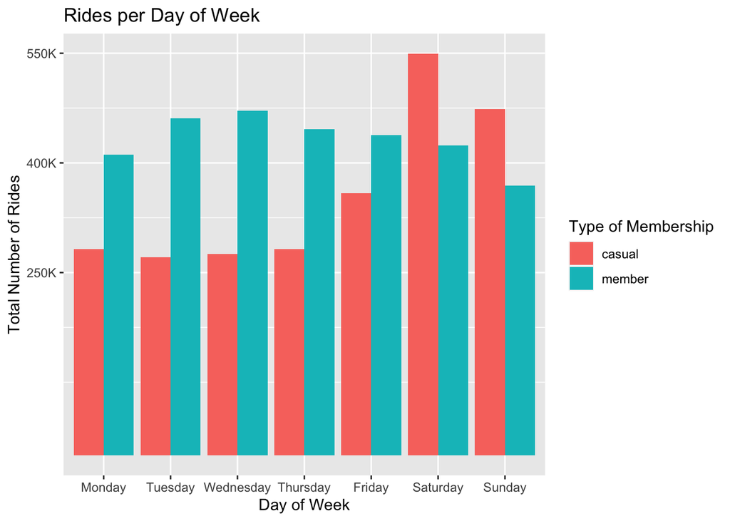

```r
bike_data1 %>%
  group_by(customer_type, weekday) %>%
  summarise(number_of_rides = n() ) %>%
  arrange(customer_type, weekday) %>%
  ggplot(aes(x = weekday, y = number_of_rides, fill = customer_type)) + geom_col(position = "dodge") +
  labs(x= 'Day of Week', y='Total Number of Rides', title='Rides per Day of Week', fill = 'Type of Membership') + scale_y_continuous(breaks = c(250000, 400000, 550000), labels = c("250K", "400K", "550K"))
```

**Figure 1** depicts that casual riders peak on the Saturday and Sunday while members peak Monday through Friday. This indicates members mainly use the bikes for their commutes and not leisure.

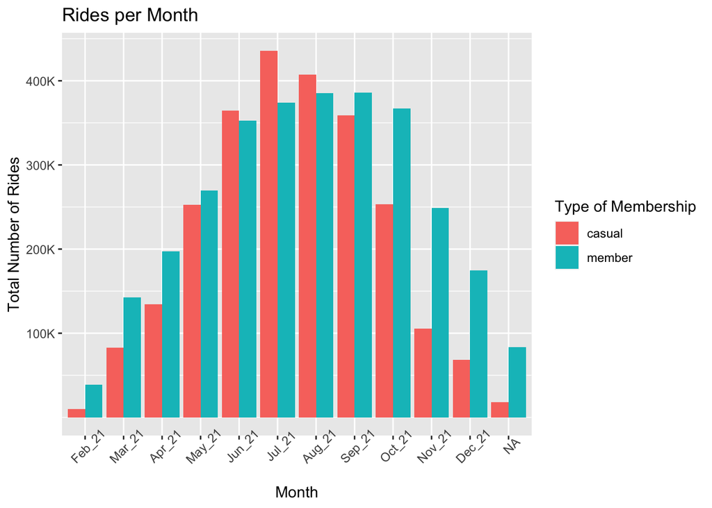

```r
bike_data1 %>%
  group_by(customer_type, month) %>%
  summarise(total_rides = n(),`average_duration_(mins)` = mean(ride_length)) %>%
  arrange(customer_type) %>%
  ggplot(aes(x = month, y = total_rides, fill = customer_type)) + geom_col(position = "dodge") +
  labs(x = "Month", y = "Total Number of Rides", title = "Rides per Month", fill = "Type of Membership") +
  scale_y_continuous(breaks = c(100000, 200000, 300000, 400000), labels = c("100K", "200K", "300K", "400K")) + theme(axis.text.x = element_text(angle = 45))
```

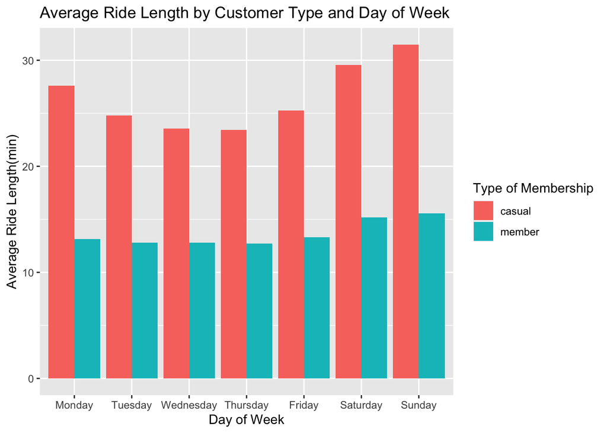

```r
bike_data1 %>%
  group_by(customer_type, weekday) %>%
  summarise(average_ride_length = mean(ride_length)) %>%
  ggplot(aes(x = weekday, y = average_ride_length, fill = customer_type)) +
  geom_col(position = "dodge") + labs (x = "Day of Week", y = "Average Ride Length(min)",
                                       title = "Average Ride Length by Customer Type and Day of Week",
                                       fill = "Type of Membership")
```

**Figure 3** displays the relationship between the average ride length of each type of customer in each day of the week. The average ride length of casual riders is considerably longer than those of members and peak on Saturday and Sunday. Annual members bike a near constant length regardless of day of week.

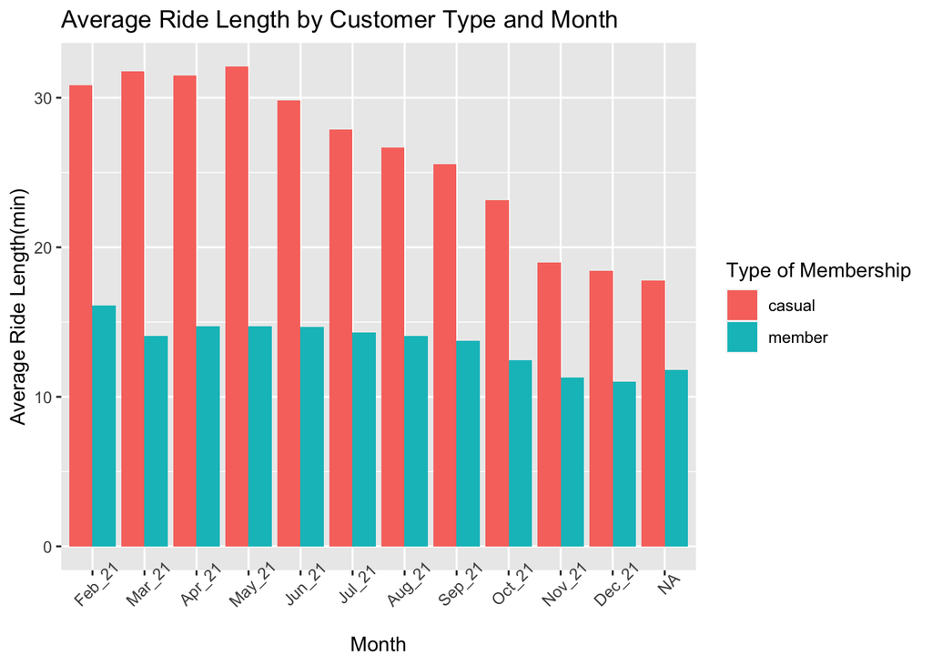

```r
bike_data1 %>%
  group_by(customer_type, month) %>%
  summarise(average_ride_length = mean(ride_length)) %>%
  ggplot(aes(x = month, y = average_ride_length, fill = customer_type))+
  geom_col(position = "dodge") +
  labs (x ="Month", y = "Average Ride Length(min)", title = "Average Ride Length by Customer Type and Month", fill = "Type of Membership") + theme(axis.text.x = element_text(angle = 45))
```

**Figure 4** illustrates the average ride length by customer type and month. Casual riders have almost double ride length compared to member riders

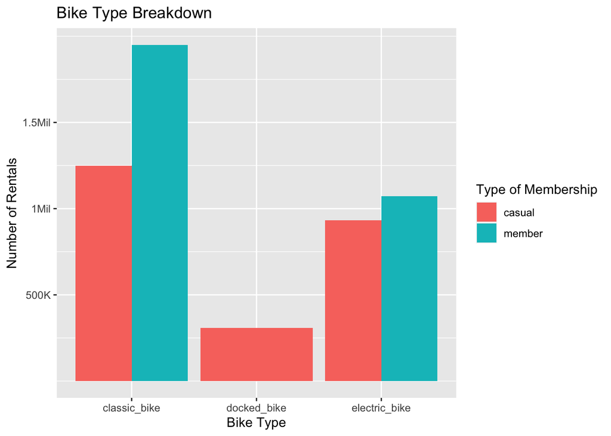

```r
bike_data1 %>%
  ggplot(aes(x = bike_type, fill = customer_type)) + geom_bar(position = "dodge") +
  labs(x = 'Bike Type', y = 'Number of Rentals', title ='Bike Type Breakdown', fill = 'Type of Membership') + scale_y_continuous(breaks = c(500000, 1000000, 1500000), labels = c("500K", "1Mil", "1.5Mil"))
```

**Figure 5** indicates bike type break down. Regarding to the graph, both member and casual rider use classic bike the most.

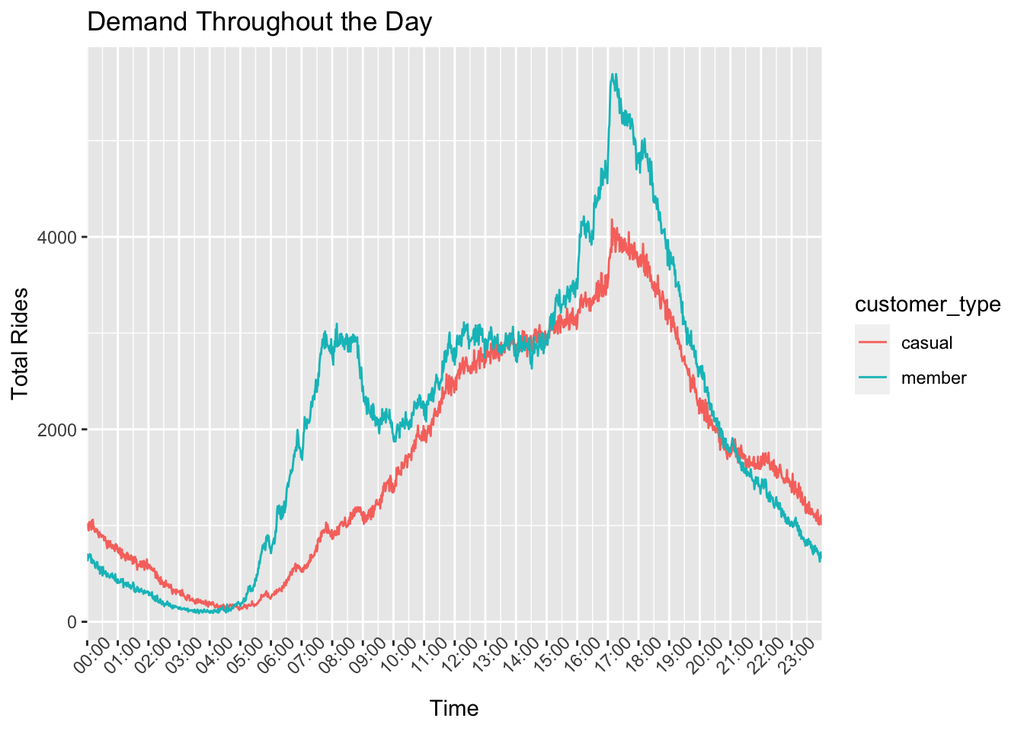

```r
bike_data1 %>%
  group_by(customer_type, time) %>%
  summarise(total_rides = n()) %>%
  ggplot(aes(x = time, y = total_rides, color = customer_type, group = customer_type)) +
  geom_line() + scale_x_datetime(date_breaks = "1 hour",
                                 date_labels = "%H:%M", expand = c(0,0)) +
  theme(axis.text.x = element_text(angle = 45)) +
  labs(title = "Demand Throughout the Day", x = "Time", y = "Total Rides")
```

**Figure 6** shows the bike demand in a 24 hour span . According to the line graph, that usage by annual members peak during rush hour to indicate many use the bikes for commutes to and from work especially with the steep drop after the peak at 5pm. Casual riders are not as volatile as there is a steady increase throughout the day with a steady decrease after the peak at 5pm.

## Act

### Recommendations

- Run promotions for annual memberships during the winter months to boost sales and try to convert casual riders into annual members
- Decrease the price of single-fare and full-day passes Monday through Friday to bolster casual ridership during the work week
- Increase price of single-fare and full-day passes on Saturday and Sunday to entice customers to convert from casual ridership into annual membership

### Additional data for further analysis

1. Age and gender - This data can show the demographics of the existing customers which could be used to target others in similar groups
2. Marital status - This data can be used for promotional use to target entire families and not just individuals
3. Pricing of plans - This data can be used to optimize the cost benefit analysis for existing customers and potential new ones
4. Household data - This data could be used for targeting potential customers in certain income ranges and/or neighborhoods